# Project: Investigate a Dataset "Online Retail"

### by Tran Nguyen

- Introduction
- Data Wrangling
- Exploratory Data Analysis
- Conclusions

## 1. Introduction

- Dataset: The file `OnlineRetail.csv` containing 541,909 rows and 8 features.
- The data consists of the information of all purchases of an online retail company in the UK during an 12 month period. The dataset can be found in the Kaggle site (https://www.kaggle.com/vijayuv/onlineretail?select=OnlineRetail.csv).
- The question I want to ask is what features are best for predicting the revenue of the company.
  - Is there any interesting feature in the dataset?
  - What is the progress of this online retail company? Does its business grow?
  - Is there any trend for product sales during different hours, days of weeks, days of the month?

With that, let's dive into the dataset.

## 2. Data Wrangling

### 1. Problem need to be fixed

- InvoiceDate is in `str` => need to change to `datetime type`
- CustomerID is in `float` => need to change to `str`
- Change the dtype `object` to `str`
- For the items with no `Description`, the `UnitPrice` is 0.0 => No meaning for data analysis => Remove all of these rows.
- Remove the item that has UnitPrice = 0
- Create a new column of Year and Month as `InvoiceYearMonth` for calculating monthly revenue.
- Create a new column for hour of day, day of week and day of month.

### 2. Create some separate dataframes for analysis

#### 2.1. Create a separate dataframe `df_revenue` for monthly metrics (revenue, growth rate, number of orders, number of active customers)

*DEFINE THE METRICS:*

- **Revenue:** Revenue = UnitPrice * Quantity.
- **Monthly Revenue:** The revenue for each month = the sum of all revenues in that month.
- **Monthly Revenue Growth Rate:** The percentage change between the current and a prior element.

#### 2.2. Create separate dataframe `df_sales` for sale with no charges/fees

It is better to remove all the non-product transaction out (debt, AMAZONFEE) before analyzing product sales for different hours of different days of the week

## 3. Exploratory Data Analysis

### The structure of the dataset

- There are 539,394 transaction items in the dataset with 8 features ('InvoiceNo', 'StockCode', 'Description', 'Quantity', 'InvoiceDate','UnitPrice', 'CustomerID', 'Country').

### The most important features in this dataset

- The 2 numeric variables 'UnitPrice' and 'Quantity', which provide us the revenue of the company.
- The 'InvoiceDate' provides us precious information about business trend and development: the revenue for weeks, months and years.
- The 'Country' field helps us to segment the data into different region groups.
- 'CustomerID' helps us to segment the data into different customer groups.

I'm most interested in figuring out what features are best for predicting the revenue of the company.

### Features in the dataset that may help support the investigation into the features of interest

I expect that the number of active customers will have the strongest effect on the number of sale product, and hence, effect the company revenue: the larger the number of active customers, the higher the sale quantity, the higher the revenue. I also think that there will be different purchasing behavior depends on the time variable: hours of day, day of the week.

Let's do exploratory data analysis to get more insight into the data.

### 3.1. Univariate Exploration

First, let have a look at the distribution of the main variable of interest: UnitPrice and Quantity.

```python
df_data_clean[['Quantity', 'UnitPrice']].describe()
```

|  | Quantity | UnitPrice |
| --- | --- | --- |
| count | 539394.000000 | 539394.000000 |
| mean | 9.845871 | 4.632614 |
| std | 215.412253 | 96.984656 |
| min | -80995.000000 | -11062.060000 |
| 25% | 1.000000 | 1.250000 |
| 50% | 3.000000 | 2.080000 |
| 75% | 10.000000 | 4.130000 |
| max | 80995.000000 | 38970.000000 |

UnitPrice and Quantity have a lot of outliers (extremely large values for both variables, also extremely negative values for `Quantity`. Let's have a look through visualization on boxplot.

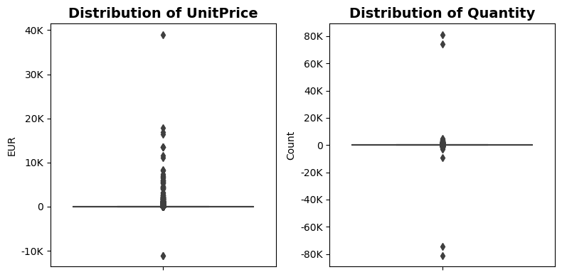

```python
### Plot using boxplot to see the distribution of the UnitPrice and Quantity.
plt.figure(figsize = (8, 4), dpi = 100)

plt.subplot(1,2,1)
sns.boxplot(data = df_data_clean, y = 'UnitPrice');
plt.title('Distribution of UnitPrice', fontdict = {'fontsize':14, 'fontweight':'bold'})
plt.ylabel('EUR')
# Hard code tick_locs for easy visualization
tick_locs = [-10000, 0, 10000, 20000, 30000, 40000]
tick_labels = ['-10K', '0','10K', '20K', '30K', '40K']
plt.yticks(tick_locs, tick_labels)

plt.subplot(1,2,2)
sns.boxplot(data = df_data_clean, y = 'Quantity');
plt.title('Distribution of Quantity', fontdict = {'fontsize':14, 'fontweight':'bold'})
plt.ylabel('Count')
# Hard code tick_locs for easy visualization
tick_locs = [-80000, -60000, -40000, -20000, 0, 20000, 40000, 60000, 80000]
tick_labels = ['-80K', '-60K','-40K', '-20K', '0', '20K', '40K', '60K', '80K']
plt.yticks(tick_locs, tick_labels)

plt.tight_layout();
```

These outliers need to be excluded to see these variables' distribution. Here we choose the max_value = 50 to plot the histogram of UnitPrice and Quantity.

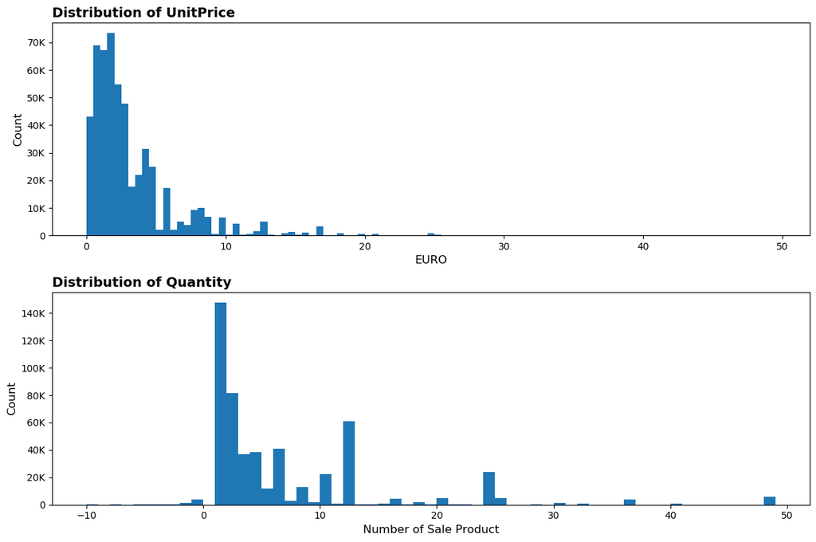

```python
# Plot histogram for UnitPrice and Quantity within a specific range.
max_value = 50
min_UnitPrice = 0
min_Quantity = -10 # return items

plt.figure(figsize = (12, 8), dpi = 100)
plt.subplot(2,1,1)
bin_edges = np.arange(min_UnitPrice, max_value, 0.5)
sns.distplot(df_data_clean['UnitPrice'], bins = bin_edges, kde = False,
            hist_kws = {'alpha' : 1});
plt.ylabel("Count", fontsize = 12)
plt.xlabel("EURO", fontsize = 12)
plt.title('Distribution of UnitPrice', loc = 'left', fontdict = {'fontsize':14, 'fontweight':'bold'})
# Hard code tick_locs for easy visualization
tick_locs = [0, 10000, 20000, 30000, 40000, 50000, 60000, 70000]
tick_labels = ['0','10K', '20K', '30K', '40K', '50K', '60K', '70K']
plt.yticks(tick_locs, tick_labels)

plt.subplot(2,1,2)
bin_edges = np.arange(min_Quantity, max_value, 1)
sns.distplot(df_data_clean['Quantity'], bins = bin_edges, kde = False,
            hist_kws = {'alpha' : 1});
plt.ylabel("Count", fontsize = 12)
plt.xlabel("Number of Sale Product", fontsize = 12)
plt.title('Distribution of Quantity', loc = 'left', fontdict = {'fontsize':14, 'fontweight':'bold'})
# Hard code tick_locs for easy visualization
tick_locs = [0, 20000, 40000, 60000, 80000, 100000, 120000, 140000]
tick_labels = ['0','20K', '40K', '60K', '80K', '100K', '120K', '140K']
plt.yticks(tick_locs, tick_labels)

plt.tight_layout();
```

UnitPrice and Quantity don't have the normal distribution; both have right-skewed distribution. Majority of these values are in the range of [0,10]. Therefore, any large purchase (in quantity or expensive item) affects a lot on the avenue of the company during the specific period of time. We have to keep that in mind for any further analysis and prediction.

### 3.2. Number of customers in different countries

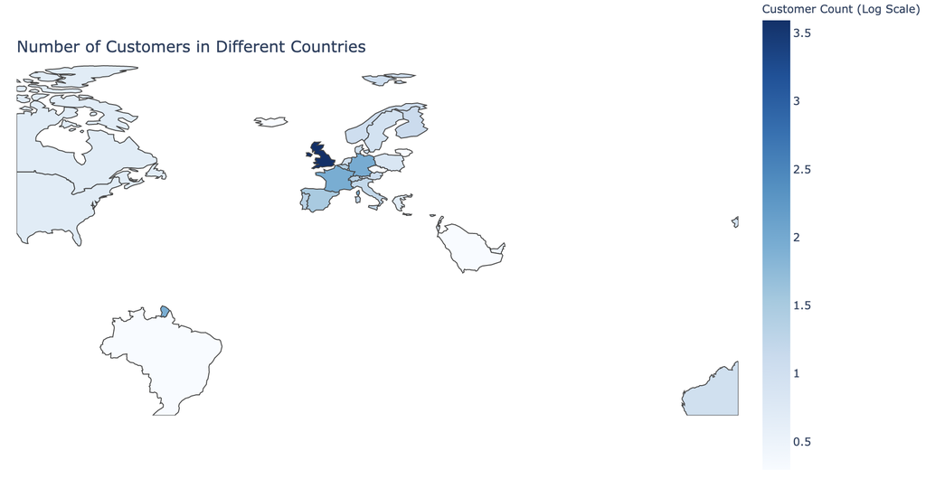

```
Percentage of unique customer in the UK in this dataset:  90.01823154056517
```

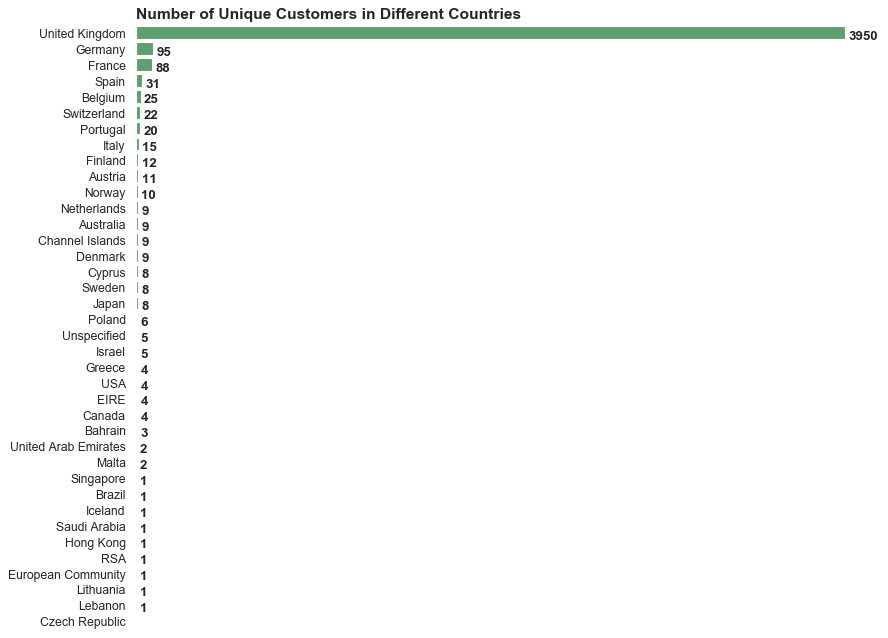

```python
### Prepare data for plot
customer_by_country = df_data_clean.groupby('Country').CustomerID.nunique().sort_values(ascending = False)
customer_by_country_index = customer_by_country.index.to_list()
customer_by_country_val = customer_by_country.values.tolist()

### Plot the number of unique customer in different countries
color = sns.color_palette()[2]
plt.figure(figsize = (12, 10), dpi = 80)
sns.barplot(customer_by_country_val, customer_by_country_index, color = color)
plt.title('Number of Unique Customers in Different Countries', loc = 'left', fontdict = {'fontsize':14, 'fontweight':'bold'});
plt.xticks([], [])

y_range = list(range(1, len(customer_by_country_index) + 1))
# Add annotation
# zip joins x and y coordinates in pairs
for x,y in zip(customer_by_country_val, y_range):
    label = x
    plt.annotate(label, # this is the text
                 (x, y - 0.4), # this is the point to label
                 textcoords = "offset points", # how to position the text
                 xytext = (3,3), # distance from text to points (x,y)
                 weight = 'bold',
                 ha = 'left') #

### Print out the percentage of unique customers in the UK comparing to the rest
print("Percentage of unique customer in the UK in this dataset: ", customer_by_country_val[0]/sum(customer_by_country_val)*100)
plt.box(False)
```

**The customers were from 38 different countries in the world. 90% of unique customers are from the UK. If we want to further investigate the customer segment, UK data should be extracted for detail analysis.**

### 3.3. Observation on the monthly metrics (revenue, growth rate, number of orders, number of active customers)

```python
print("The earliest date in the dataset: ", df_data_clean.InvoiceDate.min())
print("The latest date in the dataset:  ", df_data_clean.InvoiceDate.max())
```

```
The earliest date in the dataset:  2010-12-01 08:26:00
The latest date in the dataset:   2011-12-09 12:50:00
```

**The latest date in the dataset is December 09, 2011 => The data for December 2011 was not complete => We will obmit December 2011 from the revenue analysis.**

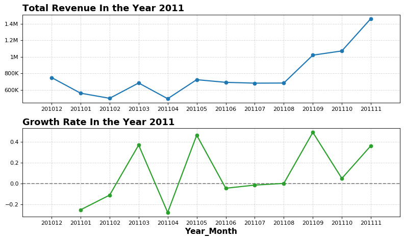

```python
### Plot Revenue GrowthRate Values to see the trend of the business

colors = sns.color_palette()

plt.figure(figsize = (10, 6), dpi = 80)

# Monthly Revenue - Sum
plt.subplot(2,1,1)
x1_range = list(range(1, df_revenue.shape[0] + 1))
plt.plot(x1_range , df_revenue['RevenueSum'], '-o', linewidth = 2, color = colors[0]);
plt.xticks([]);
plt.xlim(0, len(x1_range) + 1)
plt.title('Total Revenue In the Year 2011',
          loc = 'left', fontdict = {'fontsize':16, 'fontweight':'bold'});
plt.xticks(x1_range, df_revenue['InvoiceYearMonth']);
plt.grid(linestyle='--', alpha=0.5)
# Hard code tick_locs for easy visualization
tick_locs = [600000, 800000, 1000000, 1200000, 1400000]
tick_labels = ['600K', '800K', '1M', '1.2M', '1.4M']
plt.yticks(tick_locs, tick_labels)

# GrowthRate
plt.subplot(2,1,2)
x2_range = list(range(1, df_revenue.shape[0] + 1))
plt.plot(x2_range , df_revenue['GrowthRate'], '-o', linewidth = 2, color = colors[2]);
plt.xticks(x2_range, df_revenue['InvoiceYearMonth']);
plt.xlim(0, len(x2_range) + 1)
plt.title('Growth Rate In the Year 2011',
          loc = 'left', fontdict = {'fontsize':16, 'fontweight':'bold'});
plt.xlabel("Year_Month", fontsize = 14, fontweight = 'bold');
#Draw reference line
plt.hlines(y = 0, xmin = 0, xmax = len(x2_range) + 1,
            linestyles = 'dashed',
            colors = 'gray')
plt.grid(linestyle='--', alpha=0.5)
plt.tight_layout()
```

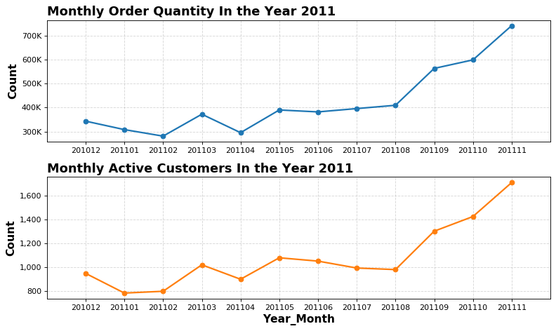

```python
### Plot the trend of number of customer/number of sale products through 12 month period:
plt.figure(figsize = (10, 6), dpi = 80)

# Plot # The number of order (quantity)
plt.subplot(2,1,1)
x1_range = list(range(1, df_revenue.shape[0] + 1))
plt.plot(x1_range , df_revenue['Quantity'], '-o', linewidth = 2, color = colors[0]);
#Decoration
plt.xlim(0, len(x1_range) + 1)
plt.title('Monthly Order Quantity In the Year 2011',
          loc = 'left', fontdict = {'fontsize':16, 'fontweight':'bold'});
plt.ylabel("Count", fontsize = 14, fontweight = 'bold');
plt.xticks(x1_range, df_revenue['InvoiceYearMonth']);
# Hard code tick_locs for easy visualization
tick_locs = [300000, 400000, 500000, 600000, 700000]
tick_labels = ['300K', '400K', '500K', '600K', '700K']
plt.yticks(tick_locs, tick_labels)
plt.grid(linestyle='--', alpha=0.5)

# The number of active customers
plt.subplot(2,1,2)
x1_range = list(range(1, df_revenue.shape[0] + 1))
plt.plot(x1_range , df_revenue['ActiveCustomer'], '-o', linewidth = 2, color = colors[1]);
#Decoration
plt.xticks([]);
plt.xlim(0, len(x1_range) + 1)
plt.title('Monthly Active Customers In the Year 2011',
          loc = 'left', fontdict = {'fontsize':16, 'fontweight':'bold'});
plt.xticks(x2_range, df_revenue['InvoiceYearMonth']);
plt.xlabel("Year_Month", fontsize = 14, fontweight = 'bold');
plt.ylabel("Count", fontsize = 14, fontweight = 'bold');
tick_locs = [800, 1000, 1200, 1400, 1600]
tick_labels = ['800', '1,000', '1,200', '1,400', '1,600']
plt.yticks(tick_locs, tick_labels)
plt.grid(linestyle='--', alpha=0.5)

plt.tight_layout()
```

### 3.4. The relationship between the number of active customers and number of orders

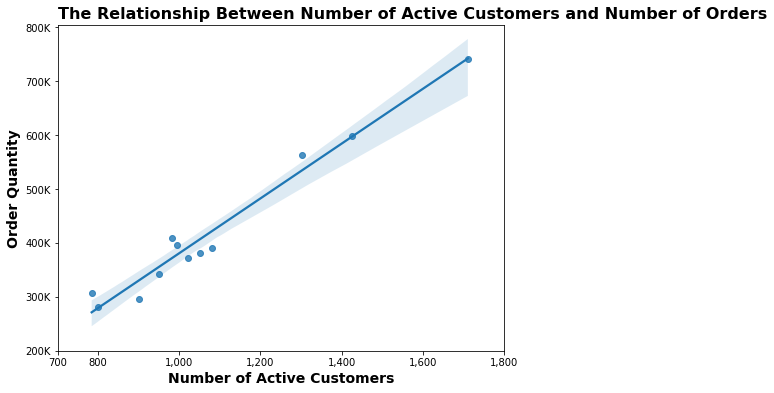

```python
### SIMPLE REGPLOT
plt.figure(figsize = (8, 6))
sns.regplot(data = df_revenue, x = 'ActiveCustomer', y = 'Quantity', color = colors[0])

plt.title('The Relationship Between Number of Active Customers and Number of Orders',
          loc = 'left', fontdict = {'fontsize':16, 'fontweight':'bold'})

plt.xlabel('Number of Active Customers', fontsize = 14, fontweight = 'bold')
plt.ylabel('Order Quantity', fontsize = 14, fontweight = 'bold');

# Hard code tick_locs for easy visualization
xtick_locs = [700, 800, 1000, 1200, 1400, 1600, 1800]
xtick_labels = ['700','800', '1,000', '1,200', '1,400', '1,600', '1,800']
plt.xticks(xtick_locs, xtick_labels)

tick_locs = [200000, 300000, 400000, 500000, 600000, 700000, 800000]
tick_labels = ['200K','300K', '400K', '500K', '600K', '700K', '800K']
plt.yticks(tick_locs, tick_labels);
```

As expected, the number of active customers in each month is highly correlated with the number of orders.

### 3.5. Monthly Charges/Fees and Product Sale Revenue

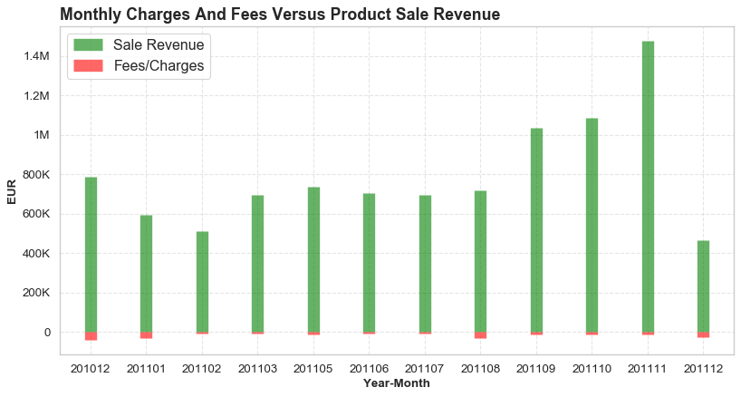

```python
### Plot monthly charge and fees and product revenue

plt.figure(figsize=(12,6), dpi= 80)

plt.vlines(x = df_revenue_chargefee.index, ymin = 0, ymax = df_revenue_chargefee.Revenue,
           color = 'green', alpha = 0.6, linewidth = 12);
plt.vlines(x = df_revenue_chargefee.index, ymin = 0, ymax = df_revenue_chargefee.ChargesFees,
           color = 'red', alpha = 0.6, linewidth = 12);
# Decorations

plt.ylabel('EUR', fontsize = 12, fontweight = 'bold')
plt.xlabel('Year-Month', fontsize = 12, fontweight = 'bold')
plt.xticks(df_revenue_chargefee.index, df_revenue_chargefee.InvoiceYearMonth, fontsize = 12)
plt.yticks(df_revenue_chargefee.index, df_revenue_chargefee.InvoiceYearMonth, fontsize = 12)
plt.title('Monthly Charges And Fees Versus Product Sale Revenue',
         loc = 'left', fontdict = {'fontsize':16, 'fontweight':'bold'})
plt.grid(linestyle='--', alpha=0.5)

# Hard code tick_locs for easy visualization
tick_locs = [0, 200000, 400000, 600000, 800000, 1000000, 1200000, 1400000]
tick_labels = ['0', '200K', '400K', '600K', '800K', '1M', '1.2M', '1.4M']
plt.yticks(tick_locs, tick_labels)
plt.legend(('Sale Revenue', "Fees/Charges"), loc = 'upper left', fontsize = 'large')
plt.show()
```

The AMAZON fees and debts negatively contributed only a very small portion in the company monthly revenue. However, these fees are very large comparing to daily revenue. Therefore, these fees were removed in the hour/daily revenue analysis.

### 3.6. The sum revenue for different hours of different days of the week

- Using the `df_sales` dataframe in which all the non-product transaction out (debt, AMAZONFEE) was removed.

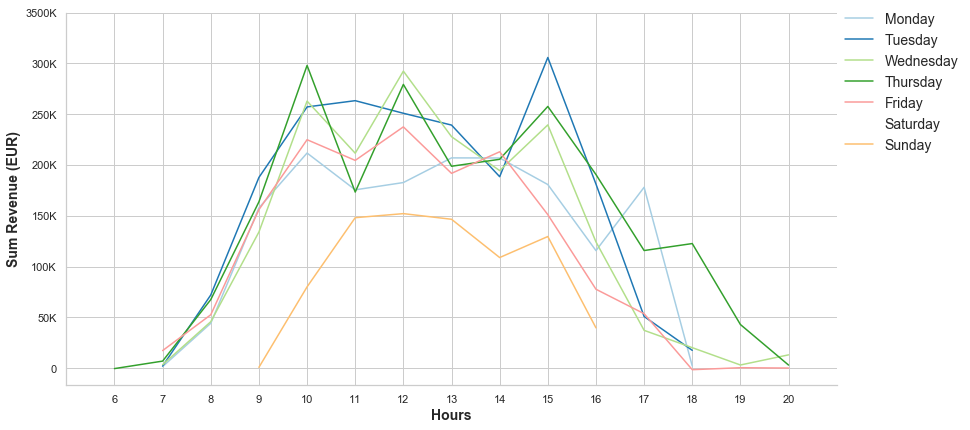

```python
### Prepare data: Revenue by hour/day of week/InvoiceYearMonth

hour_mean_revenues = df_sales.groupby(['DayOfWeek', 'Hour'])['Revenue'].sum()\
        .reset_index().rename(columns={'Revenue': 'Sum_Revenue'})

sns.set(style="whitegrid")

hours = list(range(6, 21))
g = sns.FacetGrid(data = hour_mean_revenues, hue = 'DayOfWeek',
                  hue_order = ['Monday', 'Tuesday', 'Wednesday', 'Thursday', 'Friday', 'Saturday', 'Sunday'],
                  palette = 'Paired', height = 6, aspect = 2)
g.map(plt.plot, 'Hour', 'Sum_Revenue')\
        .set(xlim=(5, 21), xticks= hours);
plt.ylabel('Sum Revenue (EUR)', fontsize = 14, fontweight = 'bold')
g.add_legend(loc = 'upper right', title = '', fontsize='14');
plt.xlabel('Hours', fontsize = 14, fontweight = 'bold')
# Hard code tick_locs for easy visualization
tick_locs = [0, 50000, 100000, 150000, 200000, 250000, 300000, 350000]
tick_labels = ['0', '50K', '100K', '150K', '200K', '250K', '300K', '3500K']
plt.yticks(tick_locs, tick_labels);
```

According to the graph, the active sale time was in **the middle of the day** where the sum revenue values are lightly higher than in the rest of the day. The sum revenue is lower in the days around weekend, which are Friday, Sunday and Monday (there is no Saturday data). Tuesday, Wednesday and Thursday where the customers purchased the most products. Let see if this trend is consistent in different months.

### 3.7. The sum revenue for different hours of different days of the week in different month

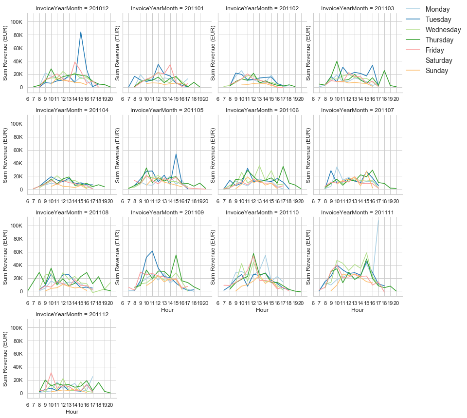

```python
### Prepare data: Revenue by hour/day of week/InvoiceYearMonth

hour_revenues = df_sales.groupby(['InvoiceYearMonth', 'DayOfWeek', 'Hour'])['Revenue'].sum().reset_index()

sns.set(style="whitegrid")
hours = list(range(6, 21))
g = sns.FacetGrid(data = hour_revenues, hue = 'DayOfWeek', col = 'InvoiceYearMonth',
                  hue_order = ['Monday', 'Tuesday', 'Wednesday', 'Thursday', 'Friday', 'Saturday', 'Sunday'],
                  palette='Paired',
                  col_wrap = 4,
                  height = 3,
                 sharex=False)
g.map(plt.plot, 'Hour', 'Revenue')\
        .set(xlim=(6, 21),
               xticks= hours, ylabel = 'Sum Revenue (EUR)')
g.add_legend(loc = 'upper right', title = '', fontsize='14');

tick_locs = [0, 20000, 40000, 60000, 80000, 100000]
tick_labels = ['0', '20K', '40K', '60K', '80K', '100K']
plt.yticks(tick_locs, tick_labels);
```

Yes, that trend seems to be quite consistent during different months of the year.

## Conclusions

#### LIMITATIONS OF THIS ANALYSIS:

- No inference statistic analysis and machine learning techniques was performed. These analyses could be used to segment customer, predict the customer lifetime value, predict sales, etc.
- My expertise is not on business/growth marketing; and this is the first time I challenged myself with this kind of data. I hope to receive more insightful suggestion and comments. Thank you!